# Avatar: The Last Airbender

Evan Jonson

8/11/2020

## Getting the Data

First, we need to read in the data from the tidytuesdayR package. Then I chose to filter out scene direction by dropping all text without character spoken words.

```r
# Load in data

tuesdata <- tidytuesdayR::tt_load('2020-08-11')
tuesdata <- tidytuesdayR::tt_load(2020, week = 33)

avatar <- tuesdata$avatar

# Filter out scene direction
avatar %<>% drop_na(character_words)
```

```r
head(avatar)
```

```
## # A tibble: 6 x 11
##      id book  book_num chapter chapter_num character full_text character_words
##   <dbl> <chr>    <dbl> <chr>         <dbl> <chr>     <chr>     <chr>
## 1     1 Water        1 The Bo~           1 Katara    Water. E~ Water. Earth. ~
## 2     3 Water        1 The Bo~           1 Sokka     It's not~ It's not getti~
## 3     5 Water        1 The Bo~           1 Katara    [Happily~ Sokka, look!
## 4     6 Water        1 The Bo~           1 Sokka     [Close-u~ Sshh! Katara, ~
## 5     8 Water        1 The Bo~           1 Katara    [Struggl~ But, Sokka! I ~
## 6    10 Water        1 The Bo~           1 Katara    [Exclaim~ Hey!
## # ... with 3 more variables: writer <chr>, director <chr>, imdb_rating <dbl>
```

## Some Textual Analysis

Now we can group by distinct books and chapters, and capture the words spoken by characters. Here I also remove stop words (i.e. common words that provide little additional information).

After this, I create a graph of the top 15 most common words over the course of the series.

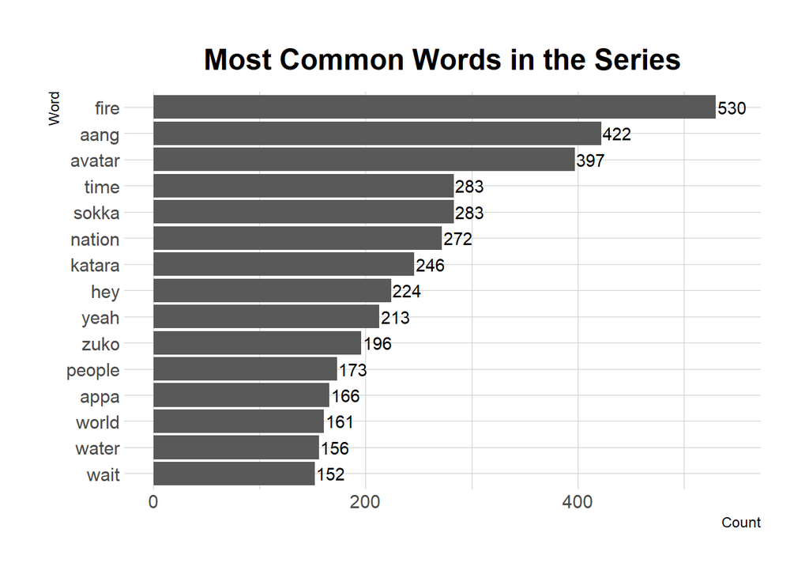

```r
tidy_words %>% ungroup %>% count(word,sort=TRUE) %>%
  slice(1:15) %>%
  mutate(word = fct_reorder(word, n)) %>%
  ggplot(aes(x=n,y=word)) +
  geom_col() +
  geom_text(aes(label=n),nudge_x=15) +
  labs(title="Most Common Words in the Series",x="Count",y="Word") +
  theme_ipsum() +
  theme(plot.title = element_text(hjust = .5))
```

And a wordcloud for good measure! We do this by creating a word_count dataframe that contains a list of each word and their frequency.

[figure not shown]

```r
wordcloud(words = word_count$word, freq = word_count$n, min.freq = 1,
          max.words=125, random.order=FALSE, rot.per=0.35,
          colors=brewer.pal(8, "Dark2"))
```

## IMDB Ratings Over Time

Finally, lets look at the IMDB ratings for the beloved series.

Here, we filter for distinct episode IMDB ratings and group them by book for graphing purposes. First, we create a single graph for each season with a smoothed line across the seasons.

```
## # A tibble: 6 x 3
## # Groups:   book [1]
##   book  chapter_num imdb_rating
##   <chr>       <dbl>       <dbl>
## 1 Water           1         8.1
## 2 Water           2         8.3
## 3 Water           3         8.5
## 4 Water           4         8.2
## 5 Water           5         8.2
## 6 Water           6         8
```

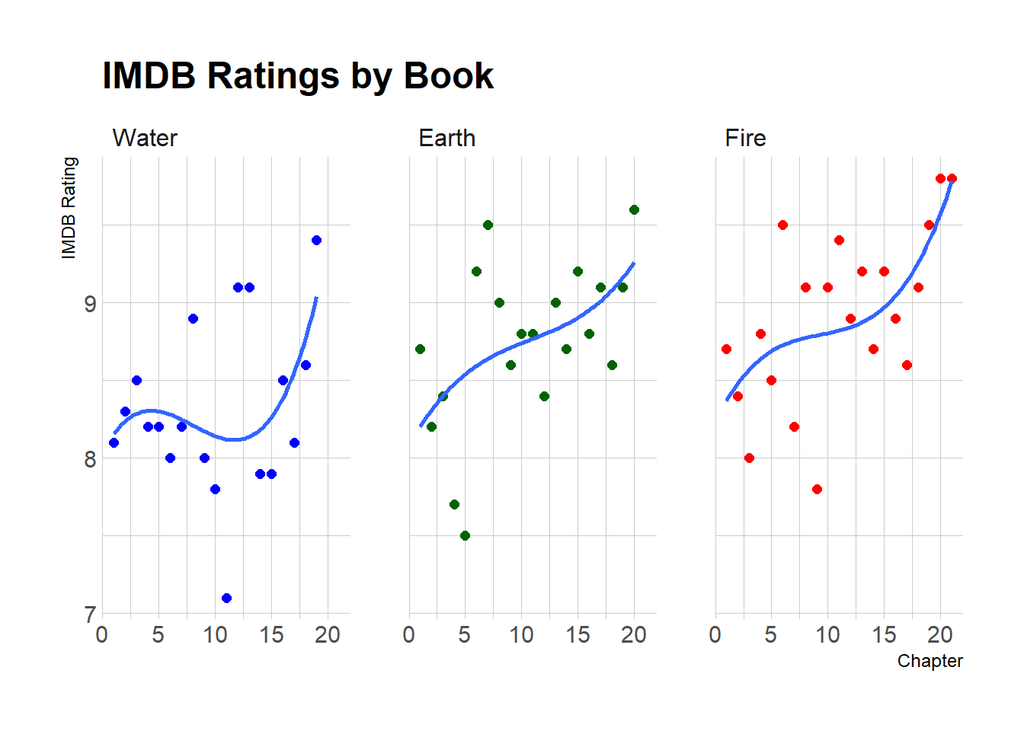

```r
# Graph separate seasons separately
ratings %>% ggplot(aes(x=chapter_num,y=imdb_rating)) +
  geom_point(aes(color=book),size=2) +
  scale_color_manual(values = c("dark green","red","blue")) +
  facet_wrap(~facet) +
  labs(x="Chapter",y="IMDB Rating",title = "IMDB Ratings by Book") +
  guides(color = FALSE) +
  geom_smooth(method = lm, formula = y ~ splines::bs(x, 3), se = FALSE) +
  theme_ipsum()
```

You’ll notice that, while the series as a whole is highly rated, every season finishes on a particularly high note. This becomes even more apparent when each season is graphed on top of one another.

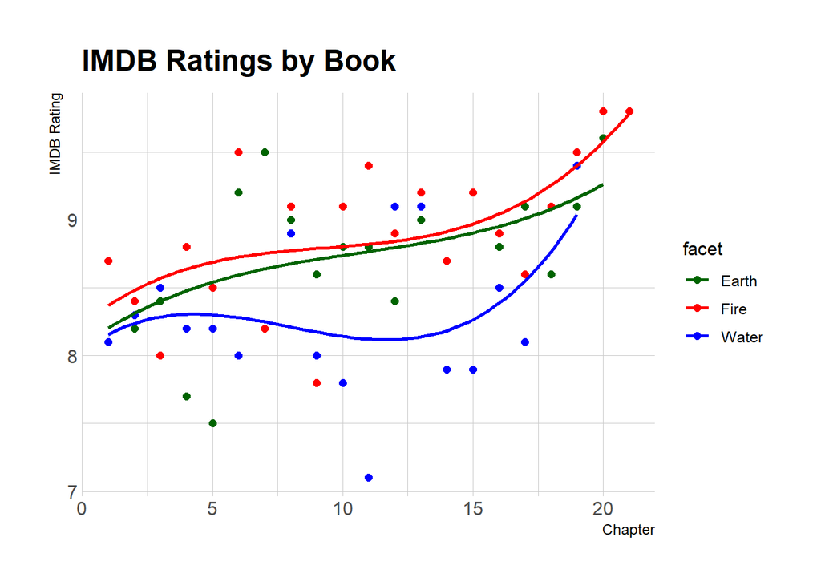

```r
ratings %>% ggplot(aes(x=chapter_num,y=imdb_rating,color=facet)) +
  geom_point(aes(color=book),size=2) +
  scale_color_manual(values = c("dark green","red","blue")) +
  labs(x="Chapter",y="IMDB Rating",title = "IMDB Ratings by Book") +
  geom_smooth(aes(group=facet),method = lm, formula = y ~ splines::bs(x, 3), se = FALSE) +
  theme_ipsum()
```

Tidy Tuesday is an R community weekly event where users create exploritory data analysis information and visual aids. More information can be found here: https://github.com/rfordatascience/tidytuesday